# BERD Workshop

Zachary F. Fisher

5/12/2022

# Preliminaries

We begin by installing and loading the gimme and multivar packages.

```r
#install.packages(c("gimme", "multivar"))
library(gimme)
library(multivar)
```

# Example Data

These data were recently made available as part of paper by Haslbeck, Ryan & Dablander (2022) at the following github site: https://github.com/jmbh/EmotionTimeSeries

You can download the .RDS data file used in this workshop from the following address:

https://github.com/jmbh/EmotionTimeSeries/tree/master/DataClean/Rowland2020

## Read in the .RDS file.

```
##   subj_id dayno beep group happy excited relaxed satisfied angry anxious depressed sad
## 1       1     1    1     2    79      64      30        74    19       7         8  58
## 2       1     1    2     2    NA      NA      NA        NA    NA      NA        NA  NA
## 3       1     1    3     2    20      24      37        36    62      41        73  67
## 4       1     1    4     2    25      24      33        29    42      68        77  81
## 5       1     1    5     2    37      24      40        17    35      36        12  76
## 6       1     1    6     2    NA      NA      NA        NA    NA      NA        NA  NA
```

## Prepare Data for Analysis

First, we Save that data as a list where each list element is one individual’s data.

To reduce the runtime of these examples we’ll select 10 individuals from the full dataset. The first 5 being from the treatment group and the second five being from the control group.

```r
subj_to_keep <- c(3,25,26,27,28,1,2,6,7,8)
vars_to_keep <- c(
     "happy",
     "excited",
     "relaxed",
     "satisfied",
     "angry",
     "anxious",
     "depressed",
     "sad"
)
data <- lapply(subj_to_keep, function(i){
     raw_data[raw_data$subj_id == i,vars_to_keep]
})
```

# GIMME: Individual-Level Only Analysis

```r
fit_indsem <- gimme::indSEM(
     data,
     out = "01_indSEM",
     standardize = TRUE
)
```

## Plots

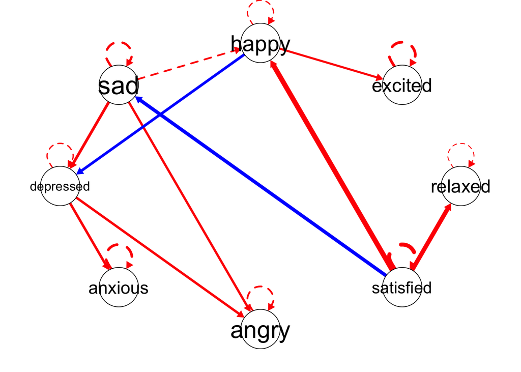

```r
plot(fit_indsem, file = "subj1")
```

# GIMME: Aggregate-Level Analysis

```r
fit_aggsem <- gimme::aggSEM(
     data,
     out = "02_aggSEM",
     standardize = TRUE
)
```

## Plots

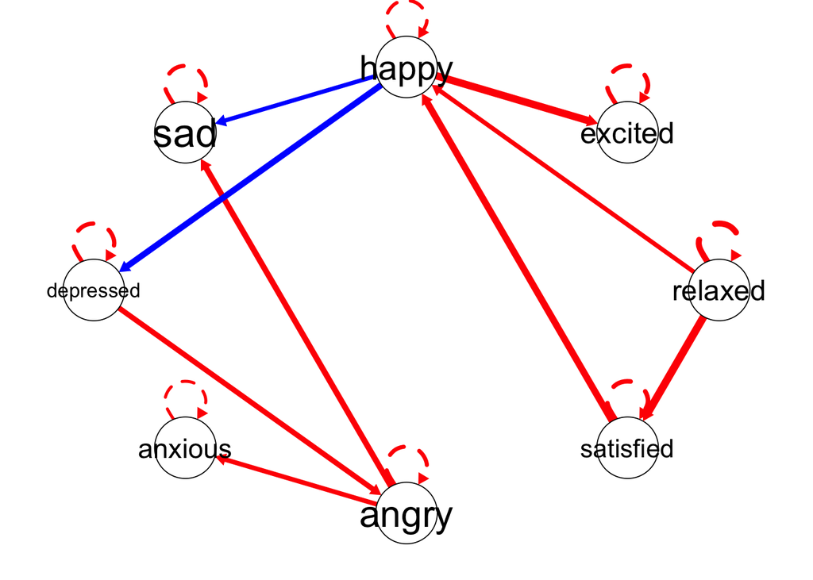

```r
plot(fit_aggsem)
```

# Standard GIMME

```r
fit_gimmesem <- gimme::gimmeSEM(
     data,
     out = "03_gimmeSEM",
     standardize = TRUE
)
```

## Plots

### Group-Level Results

```
## Please specify a file id for individual plots. Otherwise, summary plot is presented.
```

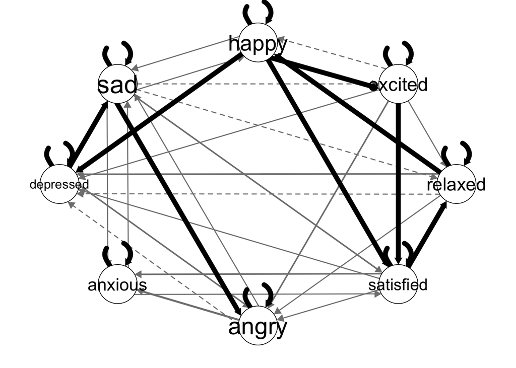

```r
plot(fit_gimmesem)
```

## Individual-Level Results

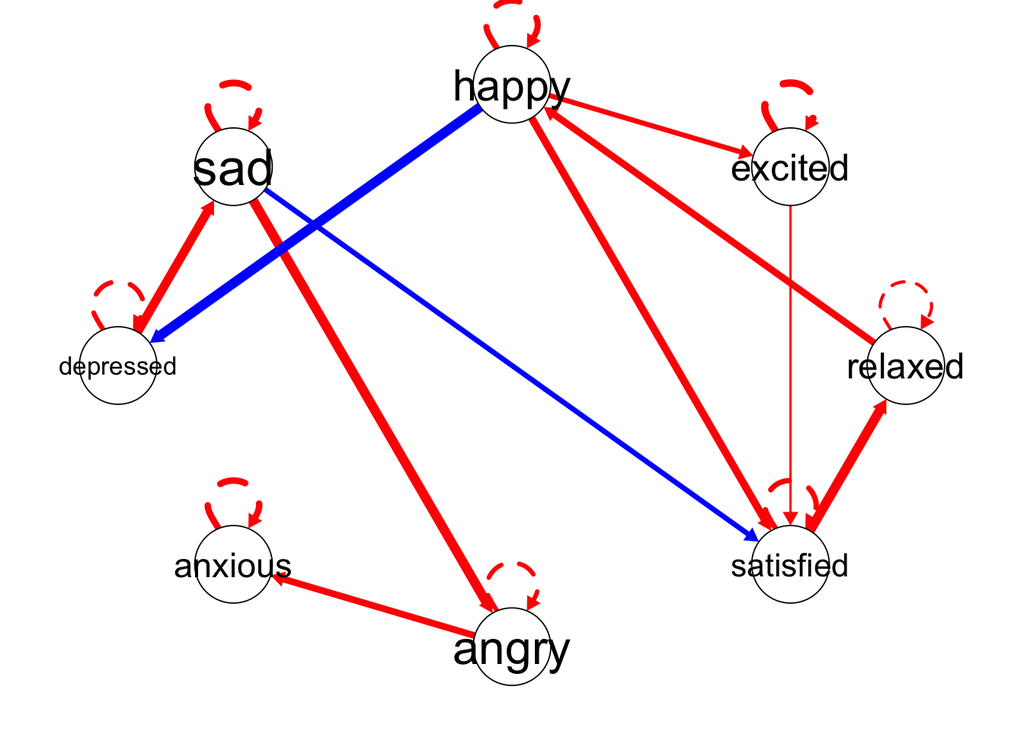

```r
plot(fit_gimmesem, file = "subj1")
```

## Estimates

```r
print(fit_gimmesem, file = "subj1")
```

```
##
## Lagged Matrix for subj1
##           happylag excitedlag relaxedlag satisfiedlag angrylag anxiouslag depressedlag
## happy         0.34       0.00       0.00         0.00     0.00       0.00         0.00
## excited       0.00       0.43       0.00         0.00     0.00       0.00         0.00
## relaxed       0.00       0.00       0.13         0.00     0.00       0.00         0.00
## satisfied     0.00       0.00       0.00         0.29     0.00       0.00         0.00
## angry         0.00       0.00       0.00         0.00     0.23       0.00         0.00
## anxious       0.00       0.00       0.00         0.00     0.00       0.37         0.00
## depressed     0.00       0.00       0.00         0.00     0.00       0.00         0.25
## sad           0.00       0.00       0.00         0.00     0.00       0.00         0.00
##           sadlag
## happy       0.00
## excited     0.00
## relaxed     0.00
## satisfied   0.00
## angry       0.00
## anxious     0.00
## depressed   0.00
## sad         0.39
##
## Contemporaneous Matrix for subj1
##           happy excited relaxed satisfied angry anxious depressed   sad
## happy      0.00    0.00    0.39       0.0  0.00       0      0.00  0.00
## excited    0.27    0.00    0.00       0.0  0.00       0      0.00  0.00
## relaxed    0.00    0.00    0.00       0.6  0.00       0      0.00  0.00
## satisfied  0.45    0.07    0.00       0.0  0.00       0      0.00 -0.28
## angry      0.00    0.00    0.00       0.0  0.00       0      0.00  0.59
## anxious    0.00    0.00    0.00       0.0  0.38       0      0.00  0.00
## depressed -0.60    0.00    0.00       0.0  0.00       0      0.00  0.00
## sad        0.00    0.00    0.00       0.0  0.00       0      0.55  0.00
```

# GIMME: Subgroup Analysis

```r
fit_sub <- gimme::gimmeSEM(
     data,
     out = "04_sub",
     standardize = TRUE,
     subgroup = TRUE
)
```

# GIMME: Confirmatory Subgroup Analysis

```r
subjname <- paste0("subj",1:10)
subgroup <- c(1,1,1,1,1,2,2,2,2,2) #create the subgroup
confirm_dataframe <- data.frame(subjname, subgroup)  #create the dataframe

fit_subcon <- gimme::gimmeSEM(
     data,
     out = "05_subcon",
     standardize = TRUE,
     subgroup = TRUE,
     confirm_subgroup = confirm_dataframe
)
```

## Plots

### All

```
## Please specify a file id for individual plots. Otherwise, summary plot is presented.
```

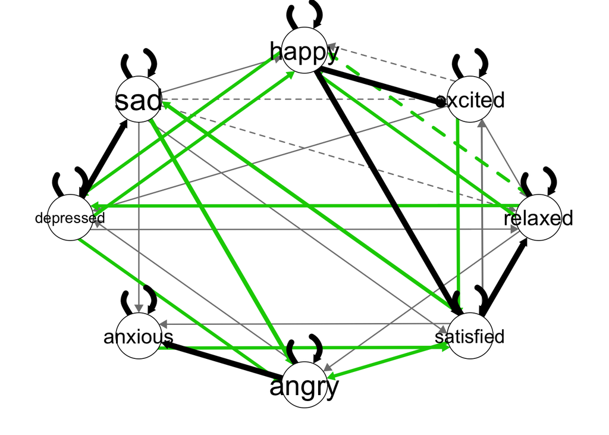

```r
plot(fit_subcon)
```

### Subgroups

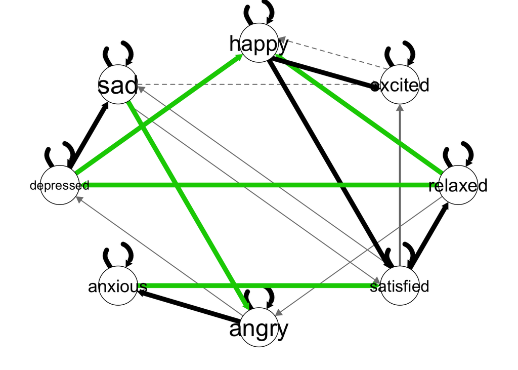

```r
plot(fit_subcon, subgroup = 1)
```

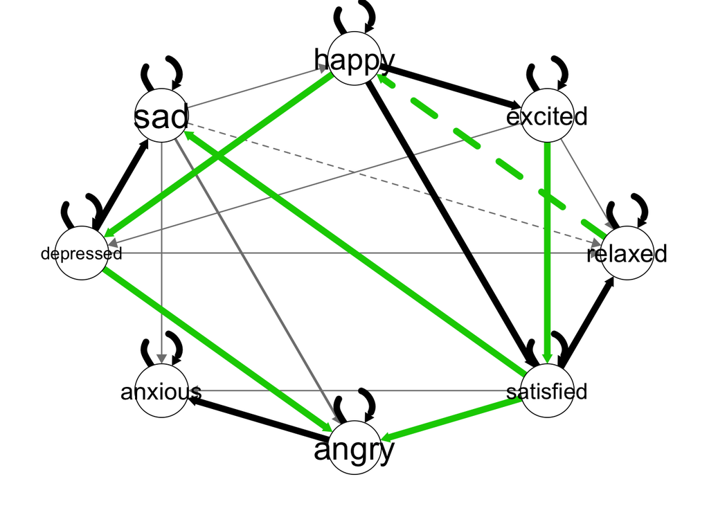

```r
plot(fit_subcon, subgroup = 2)
```

## Estimates

```r
print(fit_subcon, subgroup = 1)
```

```
##
## Lagged Count Matrix for Subgroup 1
##           happylag excitedlag relaxedlag satisfiedlag angrylag anxiouslag depressedlag
## happy            5          1          0            0        0          0            0
## excited          0          5          0            0        0          0            0
## relaxed          0          0          5            0        0          0            0
## satisfied        0          0          0            5        0          0            0
## angry            0          0          0            0        5          0            0
## anxious          0          0          0            0        0          5            0
## depressed        0          0          0            0        0          0            5
## sad              0          0          0            0        0          0            0
##           sadlag
## happy          0
## excited        1
## relaxed        0
## satisfied      0
## angry          0
## anxious        0
## depressed      0
## sad            5
##
## Contemporaneous Count Matrix for Subgroup 1
##           happy excited relaxed satisfied angry anxious depressed sad
## happy         0       0       5         0     0       0         5   0
## excited       5       0       0         2     0       0         0   0
## relaxed       0       0       0         5     0       0         0   0
## satisfied     5       0       0         0     0       5         0   1
## angry         0       0       1         0     0       0         0   5
## anxious       0       0       0         0     5       0         0   0
## depressed     0       0       5         0     1       0         0   0
## sad           0       0       0         1     0       0         5   0
```

```r
print(fit_subcon, subgroup = 1, mean = TRUE)
```

```
##
## Lagged Average Matrix for Subgroup 1
##           happylag excitedlag relaxedlag satisfiedlag angrylag anxiouslag depressedlag
## happy          0.3       0.05       0.00         0.00     0.00       0.00         0.00
## excited        0.0       0.37       0.00         0.00     0.00       0.00         0.00
## relaxed        0.0       0.00       0.28         0.00     0.00       0.00         0.00
## satisfied      0.0       0.00       0.00         0.26     0.00       0.00         0.00
## angry          0.0       0.00       0.00         0.00     0.18       0.00         0.00
## anxious        0.0       0.00       0.00         0.00     0.00       0.08         0.00
## depressed      0.0       0.00       0.00         0.00     0.00       0.00         0.15
## sad            0.0       0.00       0.00         0.00     0.00       0.00         0.00
##           sadlag
## happy       0.00
## excited     0.05
## relaxed     0.00
## satisfied   0.00
## angry       0.00
## anxious     0.00
## depressed   0.00
## sad         0.25
##
## Contemporaneous Average Matrix for Subgroup 1
##           happy excited relaxed satisfied angry anxious depressed   sad
## happy      0.00       0    0.24      0.00  0.00    0.00     -0.21  0.00
## excited    0.33       0    0.00      0.10  0.00    0.00      0.00  0.00
## relaxed    0.00       0    0.00      0.36  0.00    0.00      0.00  0.00
## satisfied  0.38       0    0.00      0.00  0.00    0.08      0.00 -0.06
## angry      0.00       0   -0.05      0.00  0.00    0.00      0.00  0.39
## anxious    0.00       0    0.00      0.00  0.24    0.00      0.00  0.00
## depressed  0.00       0   -0.23      0.00  0.08    0.00      0.00  0.00
## sad        0.00       0    0.00     -0.06  0.00    0.00      0.26  0.00
```

# GIMME: Latent Variable Analysis

```r
lv_model <- '
  neg =~ anxious + angry + sad + depressed
  pos =~ happy + excited + relaxed + satisfied
'

fit_latent <- gimme::gimmeSEM(
  data = data,
  out = "06_latent",
  standardize = TRUE,
  lv_model = lv_model
)
```

# multivar

## Data Processing

Missing data routines for multivar are still under development. For that reason we select the first 76 observations for 10 subjects.

```r
data_all <- lapply(unique(raw_data$subj_id), function(i){
     raw_data[raw_data$subj_id == i,vars_to_keep]
})
data <- lapply(data_all,function(df){df[complete.cases(df),][1:76,]})[1:10]
```

```r
model <- multivar::constructModel(data = data)
fit <- multivar::cv.multivar(model)
```

## Plot Common Effects

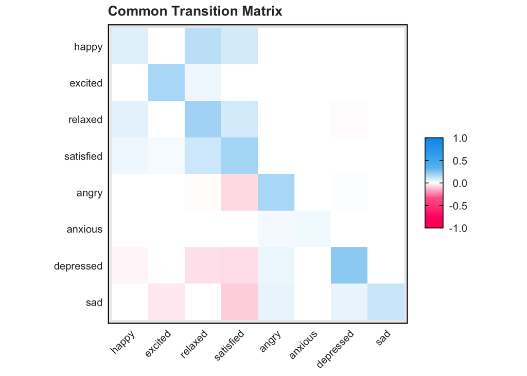

```r
plot_results(fit, plot_type = "common")
```

## Plot Total Effects Subject 1

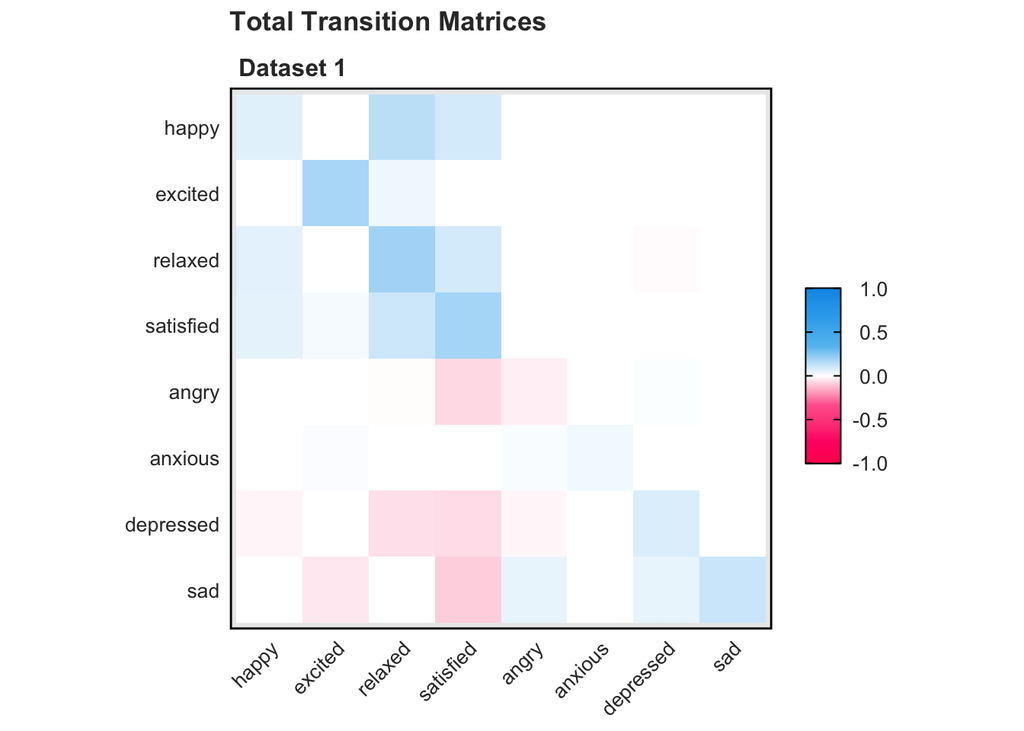

```r
plot_results(fit, plot_type = "total", datasets = 1)
```

# References

Haslbeck, J. M. B., Ryan, O., & Dablander, F. (2022). Multimodality and Skewness in Emotion Time Series. https://doi.org/10.31234/osf.io/qudr6

Rowland, Z., & Wenzel, M. (2020). Mindfulness and affect-network density: Does mindfulness facilitate disengagement from affective experiences in daily life?. Mindfulness, 11(5), 1253-1266.